# Descripción

La compañía de seguros Sure Tomorrow quiere resolver varias tareas con la ayuda de machine learning y te pide que evalúes esa posibilidad.

- Tarea 1: encontrar clientes que sean similares a un cliente determinado. Esto ayudará a los agentes de la compañía con el marketing.
- Tarea 2: predecir la probabilidad de que un nuevo cliente reciba una prestación del seguro. ¿Puede un modelo de predictivo funcionar mejor que un modelo dummy?
- Tarea 3: predecir el número de prestaciones de seguro que un nuevo cliente pueda recibir utilizando un modelo de regresión lineal.
- Tarea 4: proteger los datos personales de los clientes sin afectar al modelo del ejercicio anterior. Es necesario desarrollar un algoritmo de transformación de datos que dificulte la recuperación de la información personal si los datos caen en manos equivocadas. Esto se denomina enmascaramiento u ofuscación de datos. Pero los datos deben protegerse de tal manera que no se vea afectada la calidad de los modelos de machine learning. No es necesario elegir el mejor modelo, basta con demostrar que el algoritmo funciona correctamente.

# Preprocesamiento y exploración de datos

## Inicialización

```python
import numpy as np
import pandas as pd

import seaborn as sns
import matplotlib.pyplot as plt
from pandas.plotting import scatter_matrix

from sklearn.linear_model import LinearRegression
from sklearn.linear_model import LogisticRegression
import sklearn.metrics
import sklearn.neighbors
from sklearn.neighbors import NearestNeighbors
from sklearn.neighbors import KNeighborsClassifier
import sklearn.preprocessing

import itertools

import math
import sklearn.metrics

from sklearn.model_selection import train_test_split

from IPython.display import display

import random
```

## Carga de datos

Carga los datos y haz una revisión básica para comprobar que no hay problemas obvios.

```python
df = pd.read_csv('C:\\Users\\euni1\\Downloads\\insurance_us.csv')
```

Renombramos las columnas para que el código se vea más coherente con su estilo.

```python
df = df.rename(columns={'Gender': 'gender', 'Age': 'age', 'Salary': 'income', 'Family members': 'family_members', 'Insurance benefits': 'insurance_benefits'})
```

```python
df.sample(10)
```

|  | gender | age | income | family_members | insurance_benefits |
| --- | --- | --- | --- | --- | --- |
| 57 | 0 | 31.0 | 48900.0 | 0 | 0 |
| 1620 | 1 | 31.0 | 47800.0 | 2 | 0 |
| 4129 | 1 | 19.0 | 35600.0 | 2 | 0 |
| 3411 | 1 | 25.0 | 49000.0 | 2 | 0 |
| 2820 | 0 | 24.0 | 45200.0 | 0 | 0 |
| 3045 | 0 | 31.0 | 52500.0 | 0 | 0 |
| 3214 | 0 | 27.0 | 42900.0 | 3 | 0 |
| 3464 | 0 | 44.0 | 46700.0 | 1 | 1 |
| 4357 | 0 | 23.0 | 33100.0 | 1 | 0 |
| 2426 | 0 | 31.0 | 47600.0 | 3 | 0 |

```python
df.info()
```

```
<class 'pandas.core.frame.DataFrame'>
RangeIndex: 5000 entries, 0 to 4999
Data columns (total 5 columns):
 #   Column              Non-Null Count  Dtype
---  ------              --------------  -----
 0   gender              5000 non-null   int64
 1   age                 5000 non-null   float64
 2   income              5000 non-null   float64
 3   family_members      5000 non-null   int64
 4   insurance_benefits  5000 non-null   int64
dtypes: float64(2), int64(3)
memory usage: 195.4 KB
```

```python
# puede que queramos cambiar el tipo de edad (de float a int) aunque esto no es crucial
# escribe tu conversión aquí si lo deseas:
df['age'] = df['age'].astype(int)
```

```python
# comprueba que la conversión se haya realizado con éxito
df.info()
```

```
<class 'pandas.core.frame.DataFrame'>
RangeIndex: 5000 entries, 0 to 4999
Data columns (total 5 columns):
 #   Column              Non-Null Count  Dtype
---  ------              --------------  -----
 0   gender              5000 non-null   int64
 1   age                 5000 non-null   int32
 2   income              5000 non-null   float64
 3   family_members      5000 non-null   int64
 4   insurance_benefits  5000 non-null   int64
dtypes: float64(1), int32(1), int64(3)
memory usage: 175.9 KB
```

```python
# ahora echa un vistazo a las estadísticas descriptivas de los datos.# ¿Se ve todo bien?
```

```python
df.describe()
```

|  | gender | age | income | family_members | insurance_benefits |
| --- | --- | --- | --- | --- | --- |
| count | 5000.000000 | 5000.000000 | 5000.000000 | 5000.000000 | 5000.000000 |
| mean | 0.499000 | 30.952800 | 39916.360000 | 1.194200 | 0.148000 |
| std | 0.500049 | 8.440807 | 9900.083569 | 1.091387 | 0.463183 |
| min | 0.000000 | 18.000000 | 5300.000000 | 0.000000 | 0.000000 |
| 25% | 0.000000 | 24.000000 | 33300.000000 | 0.000000 | 0.000000 |
| 50% | 0.000000 | 30.000000 | 40200.000000 | 1.000000 | 0.000000 |
| 75% | 1.000000 | 37.000000 | 46600.000000 | 2.000000 | 0.000000 |
| max | 1.000000 | 65.000000 | 79000.000000 | 6.000000 | 5.000000 |

## Análisis exploratorio de datos

Vamos a comprobar rápidamente si existen determinados grupos de clientes observando el gráfico de pares.

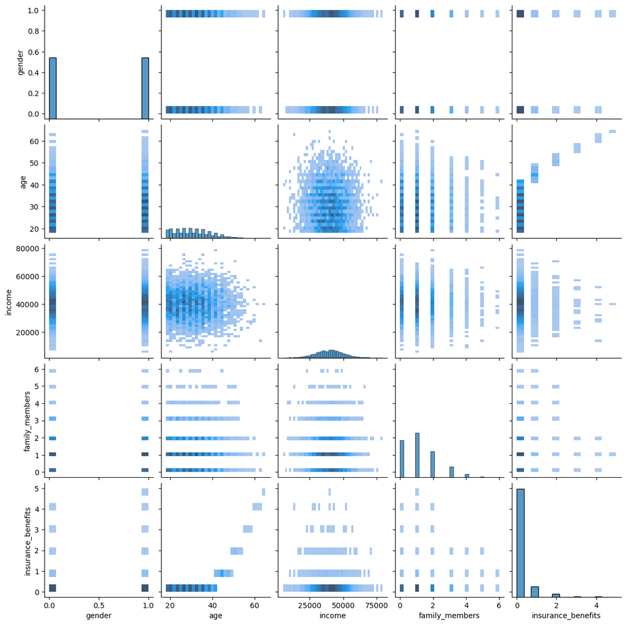

```python
g = sns.pairplot(df, kind='hist')
g.fig.set_size_inches(12, 12)
```

De acuerdo, es un poco complicado detectar grupos obvios (clústeres) ya que es difícil combinar diversas variables simultáneamente (para analizar distribuciones multivariadas). Ahí es donde LA y ML pueden ser bastante útiles.

# Tarea 1. Clientes similares

En el lenguaje de ML, es necesario desarrollar un procedimiento que devuelva los k vecinos más cercanos (objetos) para un objeto dado basándose en la distancia entre los objetos. Es posible que quieras revisar las siguientes lecciones (capítulo -> lección)- Distancia entre vectores -> Distancia euclidiana

- Distancia entre vectores -> Distancia Manhattan

Para resolver la tarea, podemos probar diferentes métricas de distancia.

Escribe una función que devuelva los k vecinos más cercanos para un $n^{th}$ objeto basándose en una métrica de distancia especificada. A la hora de realizar esta tarea no debe tenerse en cuenta el número de prestaciones de seguro recibidas. Puedes utilizar una implementación ya existente del algoritmo kNN de scikit-learn (consulta [el enlace](https://scikit-learn.org/stable/modules/generated/sklearn.neighbors.NearestNeighbors.html#sklearn.neighbors.NearestNeighbors)) o tu propia implementación. Pruébalo para cuatro combinaciones de dos casos- Escalado

- los datos no están escalados
- los datos se escalan con el escalador [MaxAbsScaler](https://scikit-learn.org/stable/modules/generated/sklearn.preprocessing.MaxAbsScaler.html)
- Métricas de distancia
  - Euclidiana
  - Manhattan

Responde a estas preguntas:- ¿El hecho de que los datos no estén escalados afecta al algoritmo kNN? Si es así, ¿cómo se manifiesta?- ¿Qué tan similares son los resultados al utilizar la métrica de distancia Manhattan (independientemente del escalado)?

```python
feature_names = ['gender', 'age', 'income', 'family_members']
```

```python
def get_knn(df, n, k, metric):

    """
    Devuelve los k vecinos más cercanos

    :param df: DataFrame de pandas utilizado para encontrar objetos similares dentro del mismo lugar
    :param n: número de objetos para los que se buscan los vecinos más cercanos
    :param k: número de vecinos más cercanos a devolver
    :param métrica: nombre de la métrica de distancia    """


    nbrs = sklearn.neighbors.NearestNeighbors(n_neighbors=k, algorithm='brute', metric=metric)
    nbrs=nbrs.fit(df[feature_names])
    nbrs_distances, nbrs_indices = nbrs.kneighbors([df.iloc[n][feature_names]], k, return_distance=True)

    df_res = pd.concat([
        df.iloc[nbrs_indices[0]],
        pd.DataFrame(nbrs_distances.T, index=nbrs_indices[0], columns=['distance'])
        ], axis=1)

    return df_res
```

Escalar datos.

```python
feature_names = ['gender', 'age', 'income', 'family_members']

transformer_mas = sklearn.preprocessing.MaxAbsScaler().fit(df[feature_names].to_numpy())

df_scaled = df.copy()
df_scaled = pd.DataFrame(transformer_mas.transform(df[feature_names]), columns=feature_names, index=df.index)
#df_scaled.loc[:, feature_names] = transformer_mas.transform(df[feature_names].to_numpy())
```

```python
df_scaled.sample(5)
```

|  | gender | age | income | family_members |
| --- | --- | --- | --- | --- |
| 4764 | 0.0 | 0.461538 | 0.397468 | 0.333333 |
| 2188 | 1.0 | 0.323077 | 0.327848 | 0.166667 |
| 4684 | 1.0 | 0.738462 | 0.513924 | 0.000000 |
| 976 | 1.0 | 0.461538 | 0.468354 | 0.500000 |
| 112 | 1.0 | 0.384615 | 0.569620 | 0.166667 |

Ahora, vamos a obtener registros similares para uno determinado, para cada combinación

```python
k=5
```

```python
n=random.randint(0, len(df_scaled))
```

```python
#metric = "euclidean"
#modelo=get_knn(df_scaled, n, k=5, metric= metric)
#modelo
```

```python
for df_source, metric in itertools.product([df, df_scaled], ['euclidean', 'manhattan']):
    if df_source is not df_scaled:
        is_scaled = False
    else:
        is_scaled = True
    print(f'metric={metric}, scaled={is_scaled}')
    modelo = get_knn(df_source, n=n, k=5, metric=metric)
    if is_scaled:
        modelo = pd.concat([df. loc[modelo.index], modelo], axis=1, keys=['original', 'scaled'])
    display(modelo)
    print()
```

```
metric=euclidean, scaled=False
```

|  | gender | age | income | family_members | insurance_benefits | distance |
| --- | --- | --- | --- | --- | --- | --- |
| 2358 | 1 | 31 | 48500.0 | 1 | 0 | 0.000000 |
| 1839 | 0 | 32 | 48500.0 | 1 | 0 | 1.414214 |
| 809 | 1 | 29 | 48500.0 | 0 | 0 | 2.236068 |
| 3524 | 1 | 29 | 48500.0 | 3 | 0 | 2.828427 |
| 2630 | 1 | 28 | 48500.0 | 0 | 0 | 3.162278 |

```
metric=manhattan, scaled=False
```

|  | gender | age | income | family_members | insurance_benefits | distance |
| --- | --- | --- | --- | --- | --- | --- |
| 2358 | 1 | 31 | 48500.0 | 1 | 0 | 0.0 |
| 1839 | 0 | 32 | 48500.0 | 1 | 0 | 2.0 |
| 809 | 1 | 29 | 48500.0 | 0 | 0 | 3.0 |
| 3524 | 1 | 29 | 48500.0 | 3 | 0 | 4.0 |
| 2630 | 1 | 28 | 48500.0 | 0 | 0 | 4.0 |

```
metric=euclidean, scaled=True
```

|  | original gender | original age | original income | original family_members | original insurance_benefits | scaled gender | scaled age | scaled income | scaled family_members | scaled distance |
| --- | --- | --- | --- | --- | --- | --- | --- | --- | --- | --- |
| 2358 | 1 | 31 | 48500.0 | 1 | 0 | 1.0 | 0.476923 | 0.613924 | 0.166667 | 0.000000 |
| 790 | 1 | 31 | 47900.0 | 1 | 0 | 1.0 | 0.476923 | 0.606329 | 0.166667 | 0.007595 |
| 38 | 1 | 31 | 49500.0 | 1 | 0 | 1.0 | 0.476923 | 0.626582 | 0.166667 | 0.012658 |
| 3388 | 1 | 31 | 47400.0 | 1 | 0 | 1.0 | 0.476923 | 0.600000 | 0.166667 | 0.013924 |
| 2165 | 1 | 32 | 48700.0 | 1 | 0 | 1.0 | 0.492308 | 0.616456 | 0.166667 | 0.015592 |

```
metric=manhattan, scaled=True
```

|  | original gender | original age | original income | original family_members | original insurance_benefits | scaled gender | scaled age | scaled income | scaled family_members | scaled distance |
| --- | --- | --- | --- | --- | --- | --- | --- | --- | --- | --- |
| 2358 | 1 | 31 | 48500.0 | 1 | 0 | 1.0 | 0.476923 | 0.613924 | 0.166667 | 0.000000 |
| 790 | 1 | 31 | 47900.0 | 1 | 0 | 1.0 | 0.476923 | 0.606329 | 0.166667 | 0.007595 |
| 38 | 1 | 31 | 49500.0 | 1 | 0 | 1.0 | 0.476923 | 0.626582 | 0.166667 | 0.012658 |
| 3388 | 1 | 31 | 47400.0 | 1 | 0 | 1.0 | 0.476923 | 0.600000 | 0.166667 | 0.013924 |
| 2165 | 1 | 32 | 48700.0 | 1 | 0 | 1.0 | 0.492308 | 0.616456 | 0.166667 | 0.017916 |

**¿Qué tan similares son los resultados al utilizar la métrica de distancia Manhattan (independientemente del escalado)?**

# Tarea 2. ¿Es probable que el cliente reciba una prestación del seguro?

En términos de machine learning podemos considerarlo como una tarea de clasificación binaria.

Con el valor de `insurance_benefits` superior a cero como objetivo, evalúa si el enfoque de clasificación kNN puede funcionar mejor que el modelo dummy. Instrucciones:

- Construye un clasificador basado en KNN y mide su calidad con la métrica F1 para k=1...10 tanto para los datos originales como para los escalados. Sería interesante observar cómo k puede influir en la métrica de evaluación y si el escalado de los datos provoca alguna diferencia. Puedes utilizar una implementación ya existente del algoritmo de clasificación kNN de scikit-learn (consulta [el enlace](https://scikit-learn.org/stable/modules/generated/sklearn.neighbors.KNeighborsClassifier.html)) o tu propia implementación.- Construye un modelo dummy que, en este caso, es simplemente un modelo aleatorio. Debería devolver "1" con cierta probabilidad. Probemos el modelo con cuatro valores de probabilidad: 0, la probabilidad de pagar cualquier prestación del seguro, 0.5, 1.

La probabilidad de pagar cualquier prestación del seguro puede definirse como $$ P\{\text{prestación de seguro recibida}\}=\frac{\text{número de clientes que han recibido alguna prestación de seguro}}{\text{número total de clientes}}. $$

Divide todos los datos correspondientes a las etapas de entrenamiento/prueba respetando la proporción 70:30.

```python
# сalcula el objetivo
df['insurance_benefits_received'] = (df['insurance_benefits'] > 0).astype(int)
```

```python
# comprueba el desequilibrio de clases con value_counts()

df['insurance_benefits_received'].value_counts()

y_true = df['insurance_benefits_received']
y_pred =  np.zeros(len(y_true))#df[feature_names].to_numpy()
X_train, X_test, y_train, y_test = train_test_split(df[feature_names], y_true, test_size=0.3, random_state=42, stratify=y_true)


# Inicializar y entrenar el modelo kNN
knn = KNeighborsClassifier(n_neighbors=5)
knn.fit(X_train, y_train)

# Realizar predicciones
y_pred = knn.predict(X_test)
```

```python
def eval_classifier(y_true, y_pred):

    f1_score = sklearn.metrics.f1_score(y_true, y_pred)
    print(f'F1: {f1_score:.2f}')

# si tienes algún problema con la siguiente línea, reinicia el kernel y ejecuta el cuaderno de nuevo
    cm = sklearn.metrics.confusion_matrix(y_true, y_pred, normalize='all')
    print('Matriz de confusión')
    # Crear el mapa de calor de la matriz
    sns.heatmap(cm, annot=True, cmap="coolwarm")
    # Mostrar el gráfico
    plt.show()
```

```python
# generar la salida de un modelo aleatorio

def rnd_model_predict(P, size, seed=42):

    rng = np.random.default_rng(seed=seed)
    return rng.binomial(n=1, p=P, size=size)
```

```
La probabilidad: 0.00
F1: 0.00
Matriz de confusión
```

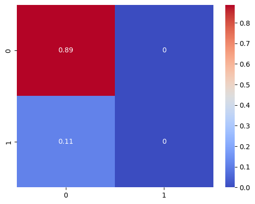

```
La probabilidad: 0.11
F1: 0.12
Matriz de confusión
```

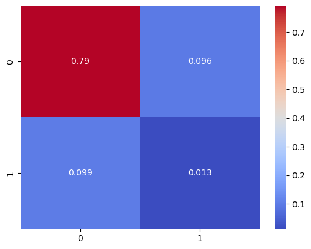

```
La probabilidad: 0.50
F1: 0.20
Matriz de confusión
```

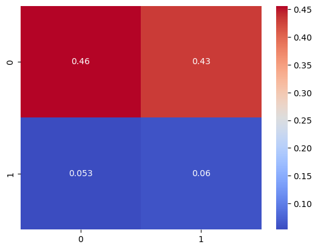

```
La probabilidad: 1.00
F1: 0.20
Matriz de confusión
```

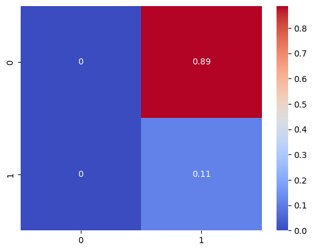

```python
for P in [0, df['insurance_benefits_received'].sum() / len(df), 0.5, 1]:

    print(f'La probabilidad: {P:.2f}')

    y_pred_rnd = rnd_model_predict(P, size=len(df))

    eval_classifier(df['insurance_benefits_received'], y_pred_rnd)

    print()
```

# Tarea 3. Regresión (con regresión lineal)

Con `insurance_benefits` como objetivo, evalúa cuál sería la RECM de un modelo de regresión lineal.

Construye tu propia implementación de regresión lineal. Para ello, recuerda cómo está formulada la solución de la tarea de regresión lineal en términos de LA. Comprueba la RECM tanto para los datos originales como para los escalados. ¿Puedes ver alguna diferencia en la RECM con respecto a estos dos casos?

Denotemos- $X$: matriz de características; cada fila es un caso, cada columna es una característica, la primera columna está formada por unidades- $y$ — objetivo (un vector)- $\hat{y}$ — objetivo estimado (un vector)- $w$ — vector de pesos La tarea de regresión lineal en el lenguaje de las matrices puede formularse así: $$ y = Xw $$

El objetivo de entrenamiento es entonces encontrar esa $w$ w que minimice la distancia L2 (ECM) entre $Xw$ y $y$:

$$ \min_w d_2(Xw, y) \quad \text{or} \quad \min_w \text{MSE}(Xw, y) $$

Parece que hay una solución analítica para lo anteriormente expuesto: $$ w = (X^T X)^{-1} X^T y $$

La fórmula anterior puede servir para encontrar los pesos $w$ y estos últimos pueden utilizarse para calcular los valores predichos $$ \hat{y} = X_{val}w $$

Divide todos los datos correspondientes a las etapas de entrenamiento/prueba respetando la proporción 70:30. Utiliza la métrica RECM para evaluar el modelo.

```python
class MyLinearRegression:

    def __init__(self):

        self.weights = None

    def fit(self, X, y):

        # añadir las unidades
        X2 = np.append(np.ones([len(X), 1]), X, axis=1)
        self.weights = np.linalg.inv(X2.T @ X2) @ X2.T @ y

    def predict(self, X):

        # añadir las unidades
        X2 = np.append(np.ones([len(X), 1]), X, axis=1)
        y_pred = X2@self.weights

        return y_pred
```

```python
def eval_regressor(y_true, y_pred):

    rmse = math.sqrt(sklearn.metrics.mean_squared_error(y_true, y_pred))
    print(f'RMSE: {rmse:.2f}')

    r2_score = sklearn.metrics.r2_score(y_true, y_pred)
    print(f'R2: {r2_score:.2f}')
```

```python
#calculo para los valores no escalados
X = df[['age', 'gender', 'income', 'family_members']].to_numpy()
y = df['insurance_benefits'].to_numpy()

X_train, X_test, y_train, y_test = train_test_split(X, y, test_size=0.3, random_state=12345)

lr = MyLinearRegression()

lr.fit(X_train, y_train)
print(lr.weights)

y_test_pred = lr.predict(X_test)
eval_regressor(y_test, y_test_pred)
```

```
[-9.43539012e-01  3.57495491e-02  1.64272726e-02 -2.60743659e-07
 -1.16902127e-02]
RMSE: 0.34
R2: 0.43
```

```python
#calculo para los valores escalados
X_ = df_scaled[['age', 'gender', 'income', 'family_members']].to_numpy()
y_ = df['insurance_benefits'].to_numpy()

X_train_, X_test_, y_train_, y_test_ = train_test_split(X_, y_, test_size=0.3, random_state=12345)

lr = MyLinearRegression()

lr.fit(X_train_, y_train_)
print(lr.weights)

y_test_pred_ = lr.predict(X_test_)
eval_regressor(y_test_, y_test_pred_)
```

```
[-0.94353901  2.32372069  0.01642727 -0.02059875 -0.07014128]
RMSE: 0.34
R2: 0.43
```

No hay cambio en los valores RMSE y R2 para los valores al ser escalados.

# Tarea 4. Ofuscar datos

Lo mejor es ofuscar los datos multiplicando las características numéricas (recuerda que se pueden ver como la matriz $X$) por una matriz invertible $P$.

$$ X' = X \times P $$

Trata de hacerlo y comprueba cómo quedarán los valores de las características después de la transformación. Por cierto, la propiedad de invertibilidad es importante aquí, así que asegúrate de que $P$ sea realmente invertible.

Puedes revisar la lección 'Matrices y operaciones matriciales -> Multiplicación de matrices' para recordar la regla de multiplicación de matrices y su implementación con NumPy.

```python
personal_info_column_list = ['gender', 'age', 'income', 'family_members']
df_pn = df[personal_info_column_list]
```

```python
X = df_pn.to_numpy()
```

Generar una matriz aleatoria $P$.

```python
rng = np.random.default_rng(seed=42)
P = rng.random(size=(X.shape[1], X.shape[1]))
```

Comprobar que la matriz P sea invertible

```python
def es_invertible(A):
    return np.linalg.det(A) != 0

print(es_invertible(P))
```

```
True
```

¿Puedes adivinar la edad o los ingresos de los clientes después de la transformación?

No, despues del metodo, los datos son irreconocibles

¿Puedes recuperar los datos originales de $X'$ si conoces $P$? Intenta comprobarlo a través de los cálculos moviendo $P$ del lado derecho de la fórmula anterior al izquierdo. En este caso las reglas de la multiplicación matricial son realmente útiles

```python
P_inv=np.linalg.inv(P)  #inversa de P
X_prima=X @ P_inv
print(X_prima)
```

```
[[  70568.57281805   79604.99119644 -101939.13289401  -76185.47202401]
 [  54048.80979419   60995.09355036  -78096.66144703  -58351.52617008]
 [  29865.34326964   33709.76115145  -43159.17256788  -32242.59233885]
 ...
 [  48239.42485765   54404.01248325  -69671.30089712  -52080.7475985 ]
 [  46529.25691386   52477.26160405  -67202.19828898  -50232.96089551]
 [  57769.74628414   65157.69802103  -83442.42062486  -62367.89488412]]
```

Muestra los tres casos para algunos clientes- Datos originales

- El que está transformado- El que está invertido (recuperado)

```python
X_recovered = X_prima @ P
df_original = pd.DataFrame(X, columns=personal_info_column_list)
df_transformed = pd.DataFrame(X_prima, columns=[f'transformed_{col}' for col in personal_info_column_list])
df_recovered = pd.DataFrame(X_recovered, columns=[f'recovered_{col}' for col in personal_info_column_list])
df_result = pd.concat([df_original, df_transformed, df_recovered], axis=1)

display(df_result)
```

|  | gender | age | income | family_members | transformed_gender | transformed_age | transformed_income | transformed_family_members | recovered_gender | recovered_age | recovered_income | recovered_family_members |
| --- | --- | --- | --- | --- | --- | --- | --- | --- | --- | --- | --- | --- |
| 0 | 1.0 | 41.0 | 49600.0 | 1.0 | 70568.572818 | 79604.991196 | -101939.132894 | -76185.472024 | 1.000000e+00 | 41.0 | 49600.0 | 1.000000e+00 |
| 1 | 0.0 | 46.0 | 38000.0 | 1.0 | 54048.809794 | 60995.093550 | -78096.661447 | -58351.526170 | -7.275958e-12 | 46.0 | 38000.0 | 1.000000e+00 |
| 2 | 0.0 | 29.0 | 21000.0 | 0.0 | 29865.343270 | 33709.761151 | -43159.172568 | -32242.592339 | -3.637979e-12 | 29.0 | 21000.0 | 1.455192e-11 |
| 3 | 0.0 | 21.0 | 41700.0 | 2.0 | 59342.634304 | 66920.460050 | -85703.149867 | -64068.139516 | -1.455192e-11 | 21.0 | 41700.0 | 2.000000e+00 |
| 4 | 1.0 | 28.0 | 26100.0 | 0.0 | 37127.303502 | 41891.423093 | -53641.127258 | -40081.321009 | 1.000000e+00 | 28.0 | 26100.0 | 1.455192e-11 |
| ... | ... | ... | ... | ... | ... | ... | ... | ... | ... | ... | ... | ... |
| 4995 | 0.0 | 28.0 | 35700.0 | 2.0 | 50793.460668 | 57295.858963 | -73369.925394 | -54837.868026 | -7.275958e-12 | 28.0 | 35700.0 | 2.000000e+00 |
| 4996 | 0.0 | 34.0 | 52400.0 | 1.0 | 74561.733635 | 84096.258688 | -107695.761998 | -80498.493300 | -1.455192e-11 | 34.0 | 52400.0 | 1.000000e+00 |
| 4997 | 0.0 | 20.0 | 33900.0 | 2.0 | 48239.424858 | 54404.012483 | -69671.300897 | -52080.747599 | -1.091394e-11 | 20.0 | 33900.0 | 2.000000e+00 |
| 4998 | 1.0 | 22.0 | 32700.0 | 3.0 | 46529.256914 | 52477.261604 | -67202.198289 | -50232.960896 | 1.000000e+00 | 22.0 | 32700.0 | 3.000000e+00 |
| 4999 | 1.0 | 28.0 | 40600.0 | 1.0 | 57769.746284 | 65157.698021 | -83442.420625 | -62367.894884 | 1.000000e+00 | 28.0 | 40600.0 | 1.000000e+00 |

5000 rows × 12 columns

Seguramente puedes ver que algunos valores no son exactamente iguales a los de los datos originales. ¿Cuál podría ser la razón de ello?

las diferencias son muy pequenas, dada la escala, son despreciables.

## Prueba de que la ofuscación de datos puede funcionar con regresión lineal

En este proyecto la tarea de regresión se ha resuelto con la regresión lineal. Tu siguiente tarea es demostrar *analytically* que el método de ofuscación no afectará a la regresión lineal en términos de valores predichos, es decir, que sus valores seguirán siendo los mismos. ¿Lo puedes creer? Pues no hace falta que lo creas, ¡tienes que que demostrarlo!

Entonces, los datos están ofuscados y ahora tenemos $X \times P$ en lugar de tener solo $X$. En consecuencia, hay otros pesos $w_P$ como

$$ w = (X^T X)^{-1} X^T y \quad \Rightarrow \quad w_P = [(XP)^T XP]^{-1} (XP)^T y $$

¿Cómo se relacionarían $w$ y $w_P$ si simplificáramos la fórmula de $w_P$ anterior?

¿Cuáles serían los valores predichos con $w_P$?

No es necesario escribir código en esta sección, basta con una explicación analítica.

**Respuesta**

la relacion es w_p = P_inv @ w. Los valores predichos con w_p serian la perturbacion que regresa a los valores originales

**Prueba analítica**

$$ w_P = [(XP)^T XP]^{-1} (XP)^T y $$$$ w_P = (XP)^{-1} ((XP)^T)^{-1} (XP)^T y $$$$ w_P = (P)^{-1} (X)^{-1} ((X)^T)^{-1} ((P)^T)^{-1} (P)^T (X)^T y $$$$ w_P = (P)^{-1} (X)^{-1} ((X)^T)^{-1} (X)^T y $$$$ w_P = (P)^{-1} ((X)^TX)^{-1}(X)^T y $$$$ w_P = (P)^{-1} w $$

## Prueba de regresión lineal con ofuscación de datos

**Procedimiento**

```python
rng = np.random.default_rng(seed=123)
P_2 = rng.random(size=(X.shape[1], X.shape[1]))
```

```python
def es_invertible(A):
    return np.linalg.det(A) != 0
print(es_invertible(P_2))

P_2inv=np.linalg.inv(P)  #inversa de P
X_2prima=X @ P_2inv
```

```
True
```

```python
class MyLinearRegression_2:

    def __init__(self):

        self.weights = None

    def fit(self, X, P, y):

        # añadir las unidades
        X2 = np.append(np.ones([len(X), 1]), X, axis=1)
        self.weights = np.linalg.inv((X2 @ P).T @ (X2 @ P)) @ (X2@ P).T @ y

    def predict(self, X):

        # añadir las unidades
        X2 = np.append(np.ones([len(X), 1]), X, axis=1)
        y_pred = X2@self.weights

        return y_pred
```

```python
#calculo para los valores no escalados

X = df[['age', 'gender', 'income', 'family_members']].to_numpy()
y = df['insurance_benefits'].to_numpy()

X_train, X_test, y_train, y_test = train_test_split(X, y, test_size=0.3, random_state=12345)

lr = MyLinearRegression()

lr.fit(X_train, y_train)
print(lr.weights)

y_test_pred = lr.predict(X_test)
eval_regressor(y_test, y_test_pred)
```

```
[-9.43539012e-01  3.57495491e-02  1.64272726e-02 -2.60743659e-07
 -1.16902127e-02]
RMSE: 0.34
R2: 0.43
```